# Data animation with gganimate and ggplot

Abiyu Giday

February 6, 2016

## Abstract:

On one of his great TED talk presentations, the renowned Swedish physician/statistician Dr. Hans Rosling’s used data animation to demonstrate the world’s life expectancytrends in wealth, health and economics.

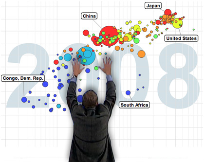

His presentations were very impressive not only because of his great explanations, but the data animation overtime demonstration that went hand in hand with it.

Few days ago, on my twitter feed, came an R package that adds animation capability to data in in realtime. Naturally, I wanted to test drive and recreate the example. The package is named `gganimate`. This package brings life to the awesome, but static, [ggplot2](https://cran.r-project.org/web/packages/ggplot2/index.html) package plots to come to life! There were additional packages that needed to be installed for the animation. The packages were `image` on R, `ffmpeg` and `ImageMagic` on Ubuntu.

With out further delay, lets get right to `gganimate`. The data for the plot comes from the [`gapminder` package](https://cran.r-project.org/web/packages/gapminder/gapminder.pdf) used by Dr. Rosling’s presentation. The table contains world’s population growth from 1952 to 2007 in 5 years increment. The data contains 1704 observations and 6 variables. The variables include Country, Continent, Year, Life Expectancy, populating and GDP per capital.

## gganimate code

```r
devtools::install_github("dgrtwo/gganimate")
library(gganimate)
library(imager)
library(gapminder)
library(ggplot2)
theme_set(theme_bw())

p1 <- ggplot(gapminder,
             aes(gdpPercap, lifeExp, size = pop, color = continent, frame = year)) +
             geom_point() +
             scale_x_log10()

#gg_animate(p1, "output1.gif")
#gg_animate(p1)
```

## The gganimate plot

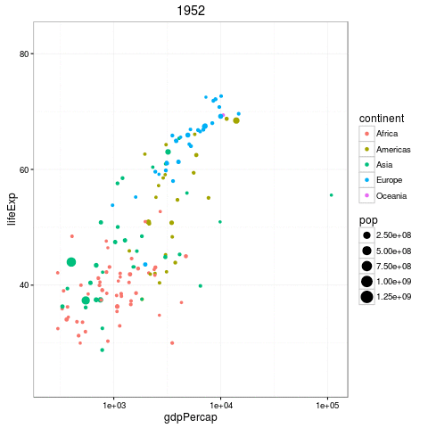

## World population data table used to generate annimated graph:

```r
library(DT)
library(gapminder)
datatable(gapminder)
```

|  | country | continent | year | lifeExp | pop | gdpPercap |
| --- | --- | --- | --- | --- | --- | --- |
| 1 | Afghanistan | Asia | 1952 | 28.801 | 8425333 | 779.4453145 |
| 2 | Afghanistan | Asia | 1957 | 30.332 | 9240934 | 820.8530296 |
| 3 | Afghanistan | Asia | 1962 | 31.997 | 10267083 | 853.10071 |
| 4 | Afghanistan | Asia | 1967 | 34.02 | 11537966 | 836.1971382 |
| 5 | Afghanistan | Asia | 1972 | 36.088 | 13079460 | 739.9811058 |
| 6 | Afghanistan | Asia | 1977 | 38.438 | 14880372 | 786.11336 |
| 7 | Afghanistan | Asia | 1982 | 39.854 | 12881816 | 978.0114388 |
| 8 | Afghanistan | Asia | 1987 | 40.822 | 13867957 | 852.3959448 |
| 9 | Afghanistan | Asia | 1992 | 41.674 | 16317921 | 649.3413952 |
| 10 | Afghanistan | Asia | 1997 | 41.763 | 22227415 | 635.341351 |

[output cut: 1694 more lines]

## Credits:

- [Gapminder - a fact based world view gorup](http://www.gapminder.org/)
- [gganimate - David Robinson](https://github.com/dgrtwo/gganimate)
- ggplot2 - The great Hadley Wickham